# California Public Schools Lookup Table

Ryan Estrellado

5/19/2017

## Purpose

The purpose of this R Notebook is to document the process used to clean the California Department of Education’s public database of public schools. This can be a very useful dataset for data scientists, analysts, or school staff, but the format of the dataset may be overwhelming to those who don’t typically work with a dataset this size or with this many columns. In particular, the dataset uses the longer fourteen digit school ID code, which can make it difficult for users to merge with a dataset that uses the commonly seen seven digit school ID code. I hope that once this dataset is cleaned, it will be a little easier to use for work projects, including:

- Making interactive `leaflet` maps using the longitude and latitude files
- Merging with other datasets, such as SEIS
- Visualizing itinerant school assignments

## Reading in the Data

The dataset we’ll be using can be found on the [California Department of Education’s website](http://www.cde.ca.gov/ds/si/ds/pubschls.asp). A description of all the variables can also be found [on the CDE website](http://www.cde.ca.gov/ds/si/ds/fspubschls.asp). This data is updated daily, so we’ll read the file in directly from the URL.

First we’ll start with reading in the data. At the time of writing, CDE makes the data available in a text format and as an excel file format. For this project we’ll use the text format.

```r
# Load the required packages

library(tidyverse)
library(readxl)
library(knitr)
library(stringr)
```

```r
original <- read_tsv("ftp://ftp.cde.ca.gov/demo/schlname/pubschls.txt")
```

You can see here that the original feel is big, both in rows and columns.

```r
dim(original)
```

```
[1] 17443    49
```

## Cleaning the Data

We’ll clean the data up by doing the following:

- Filter the `StatusType` column so that we only have `Active` schools
- Remove code fields if there is a more helpful description field
- Remove other columns school staff probably won’t need when merging with this file

```r
cde_schls <- original %>%
  filter(StatusType == "Active") %>%
  select(-c(AdmFName1:AdmEmail3, FundingType, Magnet, StatusType, Street:State, DOC, CharterNum, SOC, EdOpsCode, EILCode))
```

Users of this data file will typically need the seven digit CDS code and not the longer fourteen digit code. To make it easier to merge using the seven digit code, we’ll create a new column called `Short_CDS`.

```r
cde_schls <- cde_schls %>%
  mutate(Short_CDS = str_sub(CDSCode, 8, 20)) %>%
  select(CDSCode, Short_CDS, everything())
```

```r
# Preview the cleaned dataset

cde_schls
```

```
# A tibble: 11,481 × 28
          CDSCode Short_CDS NCESDist NCESSchool  County
            <chr>     <chr>    <chr>      <chr>   <chr>
1  01100170000000   0000000  0691051       <NA> Alameda
2  01100170112607   0112607  0691051      10947 Alameda
3  01100170123968   0123968  0691051      12844 Alameda
4  01100170124172   0124172  0691051      12901 Alameda
5  01100170125567   0125567  0691051      13008 Alameda
6  01100170130401   0130401  0691051      09264 Alameda
7  01100170130419   0130419  0691051      06830 Alameda
8  01100170131581   0131581  0691051      13887 Alameda
9  01100176001788   6001788  0691051      04257 Alameda
10 01100176002000   6002000  0691051      04288 Alameda
# ... with 11,471 more rows, and 23 more variables: District <chr>,
#   School <chr>, MailStreet <chr>, MailStrAbr <chr>, MailCity <chr>,
#   MailZip <chr>, MailState <chr>, Phone <chr>, Ext <int>, Website <chr>,
#   OpenDate <date>, ClosedDate <date>, Charter <chr>, DOCType <chr>,
#   SOCType <chr>, EdOpsName <chr>, EILName <chr>, GSoffered <chr>,
#   GSserved <chr>, Virtual <chr>, Latitude <dbl>, Longitude <dbl>,
#   LastUpdate <date>
```

## Checking for Missing Values

It’s helpful to know if there are missing values in any of the more useful fields. The following are the percentage of `NA`s in some of the fields.

```r
nas <- cde_schls %>%
  summarise(CDSCode = mean(is.na(CDSCode)), Short_CDS = mean(is.na(Short_CDS)),
            School = mean(is.na(School)), Latitude = mean(is.na(Latitude)),
            Longitude = mean(is.na(Longitude)))

kable(nas)
```

| CDSCode | Short_CDS | School | Latitude | Longitude |
| --- | --- | --- | --- | --- |
| 0 | 0 | 0.0943298 | 0.0019162 | 0.0019162 |

## Write the File as a CSV

That’s it! Finally, we’ll write the cleaned file as a csv.

```r
write_csv(cde_schls, "data/cleaned_cde_schools.csv")
```

## Sample Plot: Top Ten Biggest School Districts

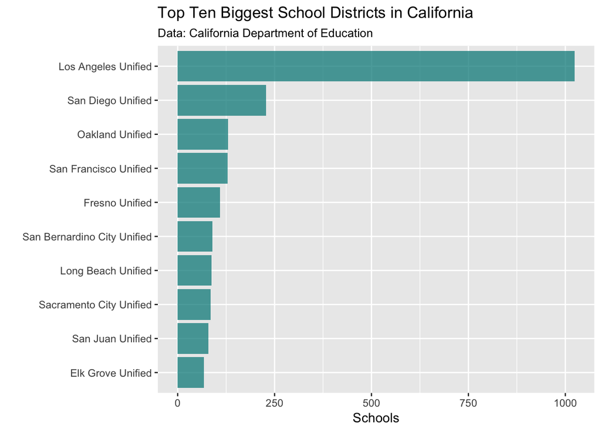

```r
# Top ten biggest school districts in CA

top_ten <- cde_schls %>%
  count(District) %>%
  filter(min_rank(-n) <= 10) %>%
  arrange(desc(n))

ggplot(data = top_ten, aes(x = reorder(District, n), y = n)) +
  geom_bar(stat = "identity", fill = "cyan4", alpha = .75) +
  coord_flip() +
  labs(title = "Top Ten Biggest School Districts in California",
       subtitle = "Data: California Department of Education",
       x = "",
       y = "Schools")
```

## Sample Plot: Map of Ten Oldest Schools

```r
# A map of the ten earliest schools in CA

library(leaflet)
library(lubridate)

ten_early <- cde_schls %>%
  select(School, Date = OpenDate, lat = Latitude, lon = Longitude) %>%
  mutate(label = paste0(year(Date), ": ", School)) %>%
  filter(min_rank(Date) <= 10) %>%
  arrange(Date)

ten_early %>%
  leaflet() %>%
  addTiles() %>%
  addMarkers(popup = ten_early$label)
```

[interactive chart not shown]